# Assignment

Sandra

2019年8月13日

# Reproducible Research assignment

## Set working directory and Loading data

```r
setwd("C:\\Users\\qitcw\\Desktop\\activity")
act <- read.csv("activity.csv")
```

## What is mean total number of steps taken per day?

### 1. Calculate the total number of steps taken per day

```r
totals <- with(act, tapply(steps, date, sum, na.rm = T))
totalsdf <-data.frame(date = names(totals), sum = totals)
```

### 2. Make a histogram of the total number of steps taken each day

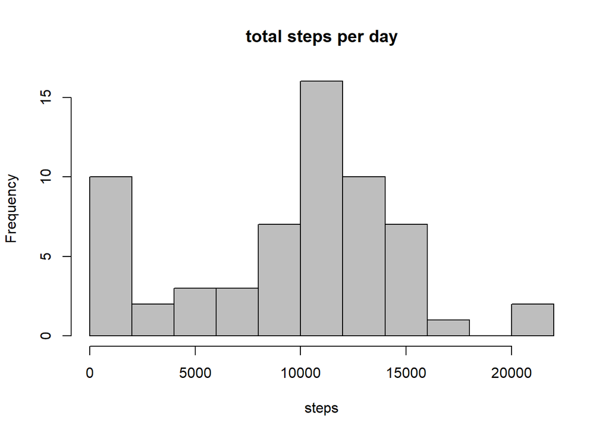

```r
plot1 <- hist(totalsdf[,2], breaks = 10, main = "total steps per day", xlab = "steps", col = "grey")
```

### 3. Calculate and report the mean and median of the total number of steps taken per day

```r
step <- as.vector(totalsdf[,2])
A <- mean(step)
B <- median(step)
```

The mean of the total number of steps taken per day is 9354.2295082. The median of the total number of steps taken per day is 10395.

## What is the average daily activity pattern?

### 1. Make a time series plot of the 5-minute interval (x-axis) and the average number of steps taken, averaged across all days (y-axis)

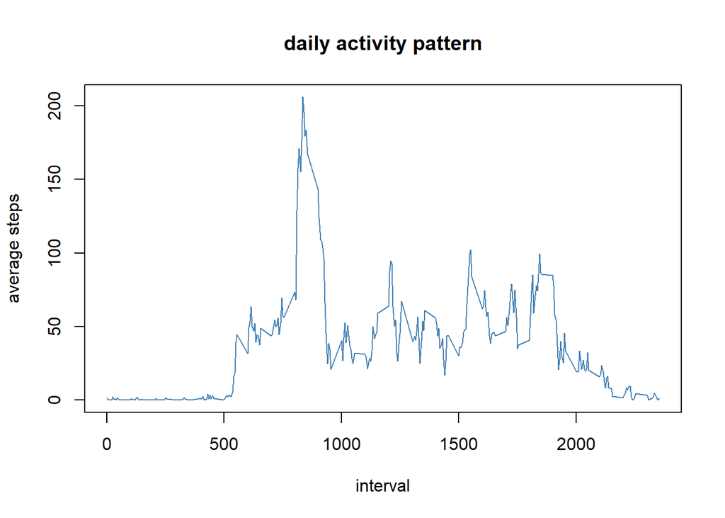

```r
ave <- aggregate(steps~interval, data = act, FUN = mean)
plot(ave$interval, ave$steps, type = "l", xlab = "interval", ylab ="average steps" ,main = "daily activity pattern", col = "steel blue" )
```

### 2. Which 5-minute interval, on average across all the days in the dataset, contains the maximum number of steps?

```r
maxmatch <- subset(ave, steps == max(ave$steps))
```

The 835, 206.1698113 interval contains the maximum number of steps.